# 5’ scRNA Combined Analysis - Ley

Load libraires

```r
library(Seurat)
library(dplyr)
library(Matrix)
```

Load the data if saved

```r
#load("5-comb.Robj")
```

Combine the 5’ datasets

```r
aml_55055.data <- Read10X(data.dir = "/mnt/analysis/marsoc/pipestances/H35TMDSXX/SC_RNA_COUNTER_PD/55055/HEAD/outs/filtered_gene_bc_matrices_mex/GRCh38/")
aml_55055 <- CreateSeuratObject(raw.data = aml_55055.data, project = "AML_55055")

aml_55054.data <- Read10X(data.dir = "/mnt/analysis/marsoc/pipestances/H35TMDSXX/SC_RNA_COUNTER_PD/55054/HEAD/outs/filtered_gene_bc_matrices_mex/GRCh38/")
aml_55054 <- CreateSeuratObject(raw.data = aml_55054.data, project = "AML_55054")

#Create the final Seurat object
aml_comb <- MergeSeurat(object1 = aml_55055, object2 = aml_55054, add.cell.id1 = "55055",
    add.cell.id2 = "55054", project = "5_AML_Comb")
```

Preprocessing

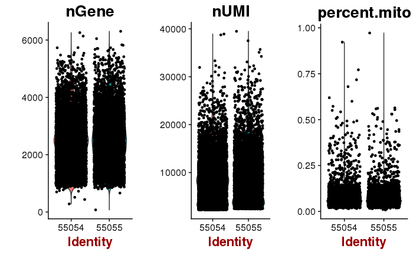

Visulize gene/gene plots

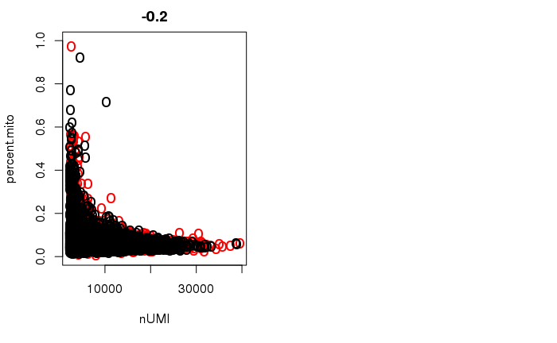

```r
# GenePlot is typically used to visualize gene-gene relationships, but can
# be used for anything calculated by the object, i.e. columns in
# object@meta.data, PC scores etc.  Since there is a rare subset of cells
# with an outlier level of high mitochondrial percentage and also low UMI
# content, we filter these as well
par(mfrow= c(1,2))
GenePlot(object = pre_aml_comb, gene1 = "nUMI", gene2 = "percent.mito", ylim = c(0,1), pch.use = "o")
GenePlot(object = pre_aml_comb, gene1 = "nUMI", gene2 = "nGene", ylim = c(0, 7000), pch.use = "o")
```

```r
# We filter out cells that have unique gene counts over 2,500 or less than
# 200 Note that low.thresholds and high.thresholds are used to define a
# 'gate' -Inf and Inf should be used if you don't want a lower or upper
# threshold.
aml_comb <- FilterCells(object = aml_comb, subset.names = c("nGene", "percent.mito"),
    low.thresholds = c(200, -Inf), high.thresholds = c(2500, 0.05))
```

Normalize the data

```r
#normalizes the gene expression measurements for each cell by the total expression, multiplies this by a scale factor (10,000 by default), and log-transforms the result.
aml_comb <- NormalizeData(object = aml_comb, normalization.method = "LogNormalize",
    scale.factor = 10000)
```

Diffirentiall expressed genes

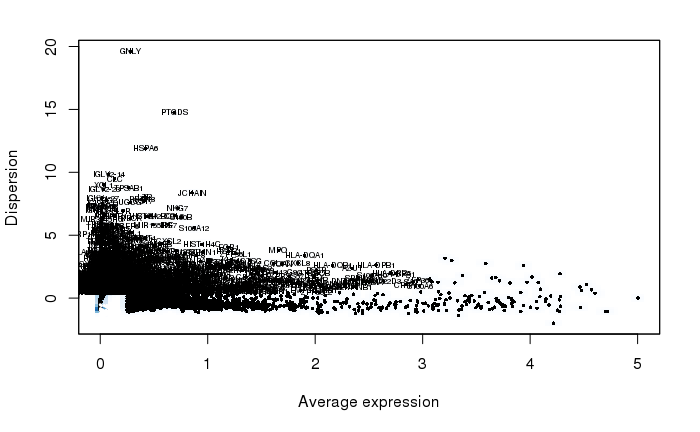

```r
aml_comb <- FindVariableGenes(object = aml_comb, mean.function = ExpMean, dispersion.function = LogVMR,
    x.low.cutoff = 0.0125, x.high.cutoff = 3, y.cutoff = 0.5)
```

```r
paste("Number of variable genes =",length(x = aml_comb@var.genes))
```

```
[1] "Number of variable genes = 8538"
```

Scaling the data and removing unwanted sources of variation

```r
aml_comb <- ScaleData(object = aml_comb, vars.to.regress = c("nUMI", "percent.mito"))
```

Perform linear dimensional reduction

```r
aml_comb <- RunPCA(object = aml_comb, pc.genes = aml_comb@var.genes, do.print = TRUE, pcs.print = 1:5,
    genes.print = 5)
```

```
[1] "PC1"
[1] "PRSS57"   "SPINK2"   "SERPINB1" "CAT"      "SPNS3"
[1] ""
[1] "CTSS"    "FCER1G"  "LGALS2"  "S100A11" "COTL1"
[1] ""
[1] ""
[1] "PC2"
[1] "JCHAIN" "TCF4"   "MEF2C"  "BLNK"   "MZB1"
[1] ""
[1] "AZU1"   "RNASE2" "APLP2"  "CTSG"   "CSTA"
[1] ""
[1] ""
[1] "PC3"
[1] "KIAA0101" "TUBA1B"   "TYMS"     "STMN1"    "C12orf75"
[1] ""
[1] "KIAA0125"    "CD34"        "AC016735.1"  "CD36"        "AL122127.25"
[1] ""
[1] ""
[1] "PC4"
[1] "IL32"   "CD3E"   "LCK"    "TRBC2"  "SPOCK2"
[1] ""
[1] "HLA-DRB5" "DERL3"    "FAM129C"  "SERPINF1" "CCDC50"
[1] ""
[1] ""
[1] "PC5"
[1] "RRM2"     "UBE2C"    "TYMS"     "KIAA0101" "TK1"
[1] ""
[1] "S100B" "PLD4"  "BASP1" "PKIB"  "GAS6"
[1] ""
[1] ""
```

Examine and visualize PCA results a few different ways

PCA table

```r
PrintPCA(object = aml_comb, pcs.print = 1:5, genes.print = 5, use.full = FALSE)
```

```
[1] "PC1"
[1] "PRSS57"   "SPINK2"   "SERPINB1" "CAT"      "SPNS3"
[1] ""
[1] "CTSS"    "FCER1G"  "LGALS2"  "S100A11" "COTL1"
[1] ""
[1] ""
[1] "PC2"
[1] "JCHAIN" "TCF4"   "MEF2C"  "BLNK"   "MZB1"
[1] ""
[1] "AZU1"   "RNASE2" "APLP2"  "CTSG"   "CSTA"
[1] ""
[1] ""
[1] "PC3"
[1] "KIAA0101" "TUBA1B"   "TYMS"     "STMN1"    "C12orf75"
[1] ""
[1] "KIAA0125"    "CD34"        "AC016735.1"  "CD36"        "AL122127.25"
[1] ""
[1] ""
[1] "PC4"
[1] "IL32"   "CD3E"   "LCK"    "TRBC2"  "SPOCK2"
[1] ""
[1] "HLA-DRB5" "DERL3"    "FAM129C"  "SERPINF1" "CCDC50"
[1] ""
[1] ""
[1] "PC5"
[1] "RRM2"     "UBE2C"    "TYMS"     "KIAA0101" "TK1"
[1] ""
[1] "S100B" "PLD4"  "BASP1" "PKIB"  "GAS6"
[1] ""
[1] ""
```

PCA viz

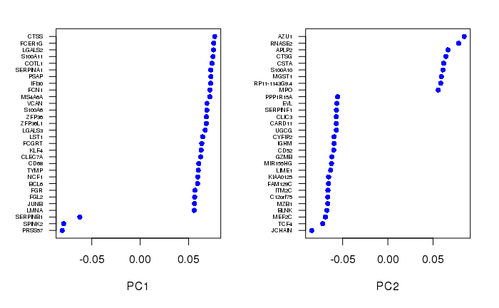

```r
VizPCA(object = aml_comb, pcs.use = 1:2)
```

PCA plot

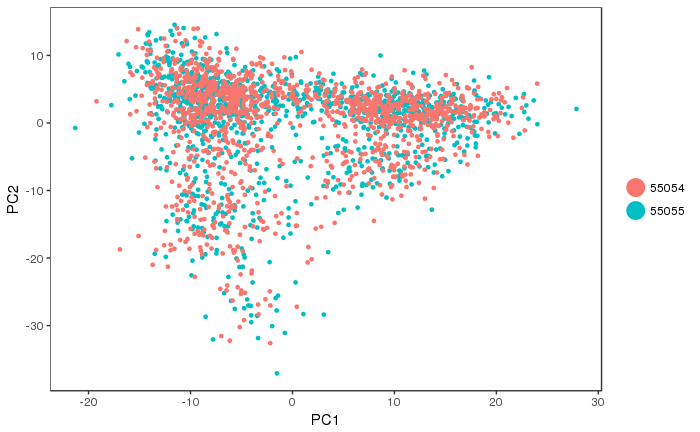

```r
PCAPlot(object = aml_comb, dim.1 = 1, dim.2 = 2)
```

```r
# ProjectPCA scores each gene in the dataset (including genes not included
# in the PCA) based on their correlation with the calculated components.
# Though we don't use this further here, it can be used to identify markers
# that are strongly correlated with cellular heterogeneity, but may not have
# passed through variable gene selection.  The results of the projected PCA
# can be explored by setting use.full=T in the functions above
aml_comb <- ProjectPCA(object = aml_comb, do.print = FALSE)
```

Heatmaps

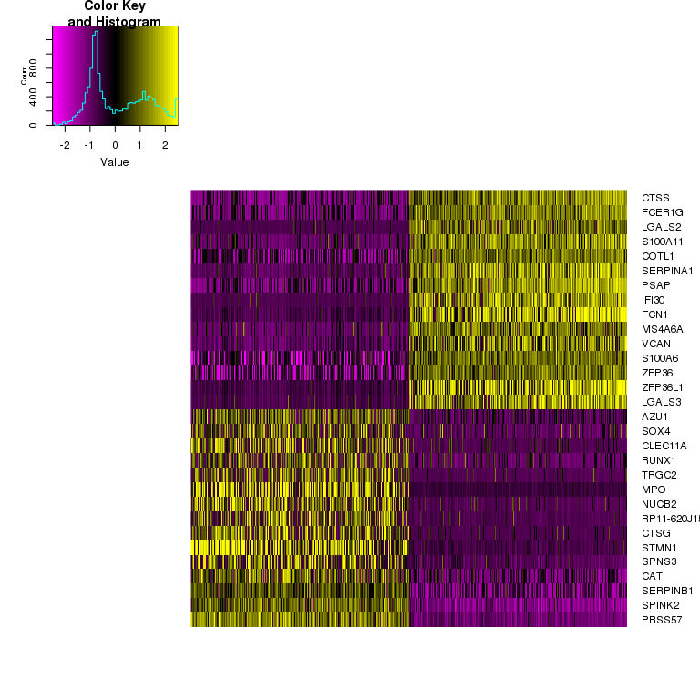

```r
PCHeatmap(object = aml_comb, pc.use = 1, cells.use = 500, do.balanced = TRUE, label.columns = FALSE)
```

Look at more PCs

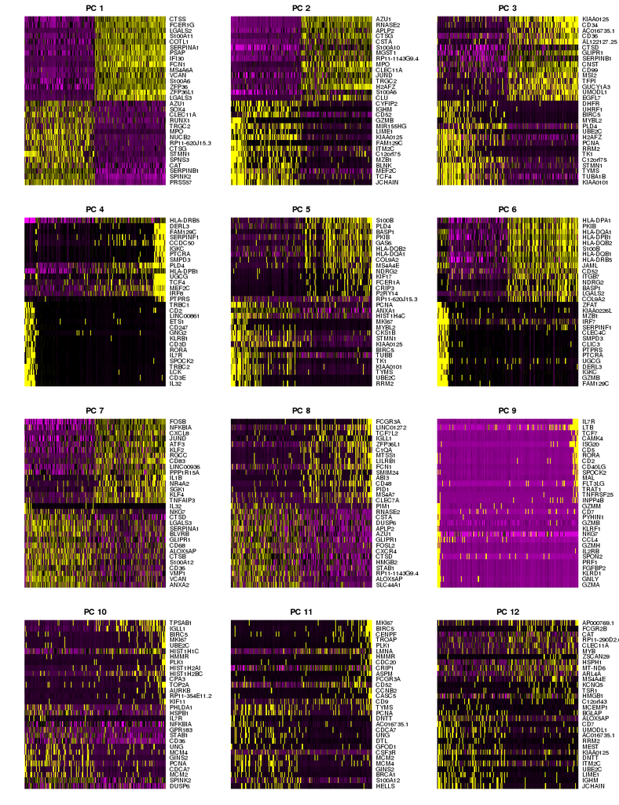

```r
PCHeatmap(object = aml_comb, pc.use = 1:12, cells.use = 500, do.balanced = TRUE,
    label.columns = FALSE, use.full = FALSE)
```

Determine statistically significant principal components

```r
# NOTE: This process can take a long time for big datasets, comment out for
# expediency.  More approximate techniques such as those implemented in
# PCElbowPlot() can be used to reduce computation time
aml_comb <- JackStraw(object = aml_comb, num.replicate = 100, do.print = TRUE)
```

Plot the PCs

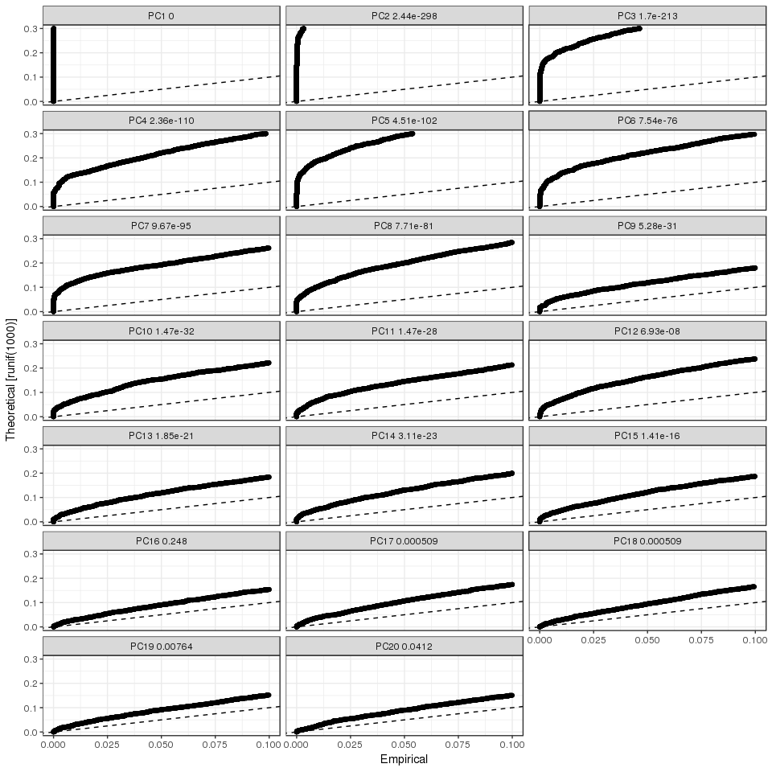

```r
JackStrawPlot(object = aml_comb, PCs = 1:20)
```

Plot the PCs and pick a cutoff at the elbow

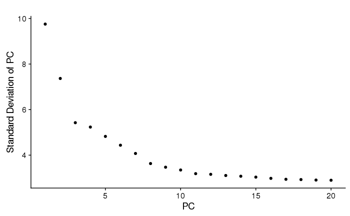

```r
PCElbowPlot(object = aml_comb)
```

## Cluster the cells

```r
# save.SNN = T saves the SNN so that the clustering algorithm can be rerun
# using the same graph but with a different resolution value (see docs for
# full details)
aml_comb <- FindClusters(object = aml_comb, reduction.type = "pca", dims.use = 1:10,
    resolution = 0.6, print.output = 0, save.SNN = TRUE)
```

Run Non-linear dimensional reduction (tSNE) and plot

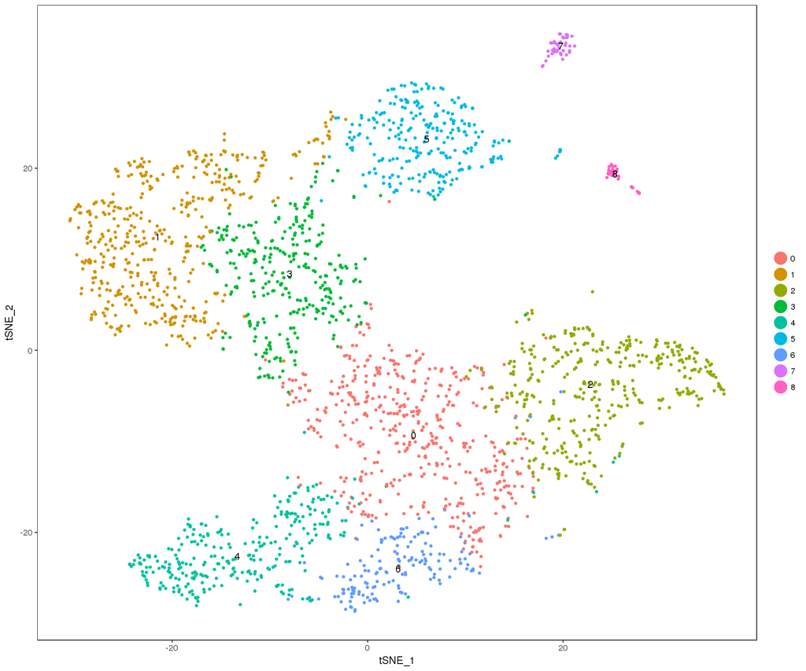

```r
aml_comb <- RunTSNE(object = aml_comb, dims.use = 1:10, do.fast = TRUE)
TSNEPlot(object = aml_comb, do.label = T)
```

Save the R object

```r
save(aml_comb,mito.genes,percent.mito, file = "5-comb.Robj")
```

### Find distinguising cluster markers

Investigate the clusters

```r
# find all markers of cluster 1
cluster1.markers <- FindMarkers(object = aml_comb, ident.1 = 1, min.pct = 0.25)
```

```r
print(x = head(x = cluster1.markers, n = 10))
```

|  | p_val | avg_logFC | pct.1 | pct.2 | p_val_adj |
| --- | --- | --- | --- | --- | --- |
| ZFP36L1 | 4.787233e-244 | 1.825652 | 0.854 | 0.129 | 1.613010e-239 |
| FCN1 | 4.136118e-216 | 1.526587 | 0.861 | 0.149 | 1.393623e-211 |
| FTH1 | 1.548853e-207 | 1.484890 | 1.000 | 0.984 | 5.218707e-203 |
| FTL | 2.673652e-191 | 1.246983 | 1.000 | 0.999 | 9.008602e-187 |
| MAFB | 3.116033e-182 | 1.387584 | 0.534 | 0.037 | 1.049916e-177 |
| NEAT1 | 1.279680e-175 | 1.282324 | 1.000 | 0.942 | 4.311752e-171 |
| PSAP | 1.734108e-167 | 1.387335 | 0.985 | 0.620 | 5.842903e-163 |
| CTSS | 2.488301e-163 | 1.208195 | 0.989 | 0.622 | 8.384081e-159 |
| KLF4 | 2.423874e-161 | 1.322482 | 0.887 | 0.315 | 8.167002e-157 |
| SERPINA1 | 4.566241e-161 | 1.217105 | 0.901 | 0.313 | 1.538549e-156 |

```r
# find all markers distinguishing cluster 6 from clusters 0-5
cluster6.markers <- FindMarkers(object = aml_comb, ident.1 = 6, ident.2 = c(0:5),
    min.pct = 0.25)
print(x = head(x = cluster6.markers, n = 10))
```

[output not shown]

```r
# find all markers distinguishing cluster 7 from clusters 0-5
cluster7.markers <- FindMarkers(object = aml_comb, ident.1 = 7, ident.2 = c(0:5),
    min.pct = 0.25)
print(x = head(x = cluster7.markers, n = 10))
```

[output not shown]

cluster 8 probably cytotoxic T lymphocytes or natural killer cells

```r
# find all markers distinguishing cluster 8 from clusters 0-5
cluster8.markers <- FindMarkers(object = aml_comb, ident.1 = 8, ident.2 = c(0:5),
    min.pct = 0.25)
print(x = head(x = cluster8.markers, n = 10))
```

[output not shown]

Find markers for all clusters

| p_val | avg_logFC | pct.1 | pct.2 | p_val_adj | cluster | gene |
| --- | --- | --- | --- | --- | --- | --- |
| 1.968104e-115 | 1.1238803 | 0.954 | 0.488 | 6.631330e-111 | 0 | AZU1 |
| 3.022747e-110 | 0.8530403 | 0.990 | 0.762 | 1.018484e-105 | 0 | SERPINB1 |
| 4.787233e-244 | 1.8256522 | 0.854 | 0.129 | 1.613010e-239 | 1 | ZFP36L1 |
| 4.136118e-216 | 1.5265870 | 0.861 | 0.149 | 1.393623e-211 | 1 | FCN1 |
| 5.653637e-194 | 1.5623156 | 0.870 | 0.203 | 1.904936e-189 | 2 | STMN1 |
| 2.748644e-156 | 1.5037860 | 0.964 | 0.565 | 9.261282e-152 | 2 | H2AFZ |
| 5.444466e-161 | 2.0578966 | 0.962 | 0.300 | 1.834458e-156 | 3 | S100A8 |
| 1.506825e-155 | 1.8222476 | 0.997 | 0.356 | 5.077095e-151 | 3 | S100A9 |
| 2.619233e-217 | 1.6026796 | 0.844 | 0.116 | 8.825245e-213 | 4 | KIAA0125 |
| 1.001056e-85 | 1.6067662 | 0.390 | 0.048 | 3.372957e-81 | 4 | JCHAIN |

[output cut: 8 more lines]

Test clasification based on ROC

```r
cluster1.markers <- FindMarkers(object = aml_comb, ident.1 = 0, thresh.use = 0.25,
    test.use = "roc", only.pos = TRUE)
```

For all plots below can use `do.return = TRUE` to get the ggplot objects stored in a list.

Plot gene expression across the clusters

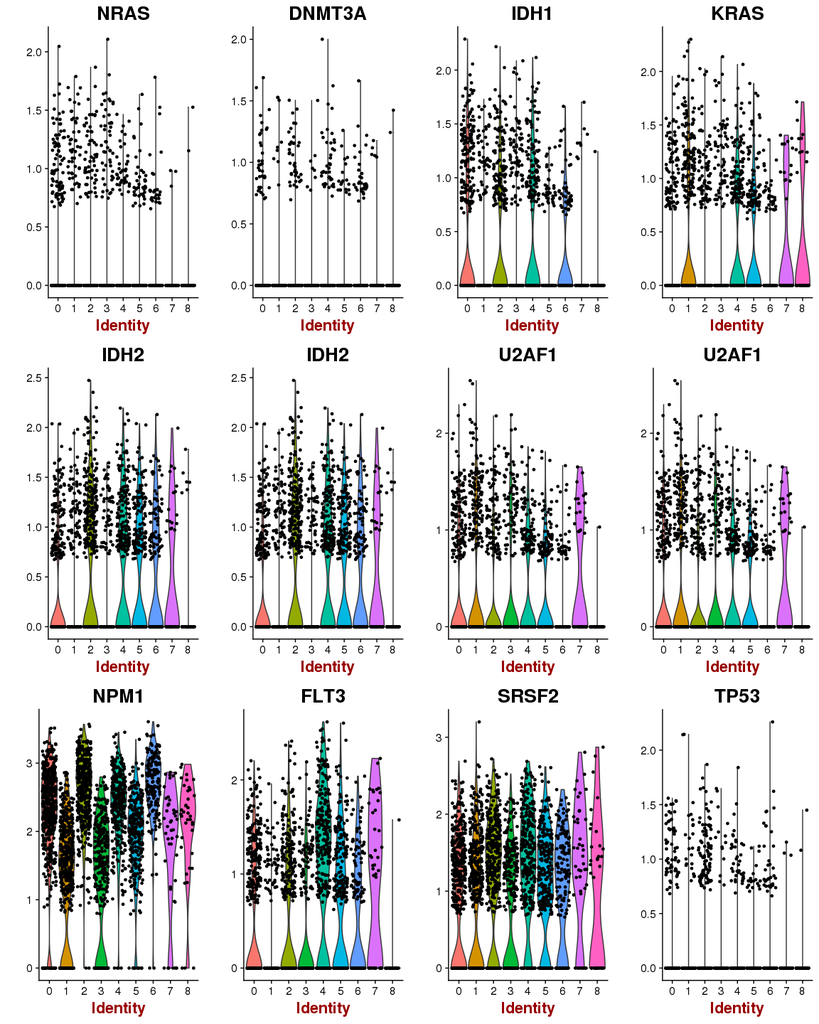

```r
VlnPlot(object = aml_comb, features.plot = c("NRAS", "DNMT3A",  "IDH1", "KRAS", "IDH2", "IDH2", "U2AF1",    "U2AF1",    "NPM1", "FLT3", "SRSF2",    "TP53"))
```

Plot UMI acrosst the clusters

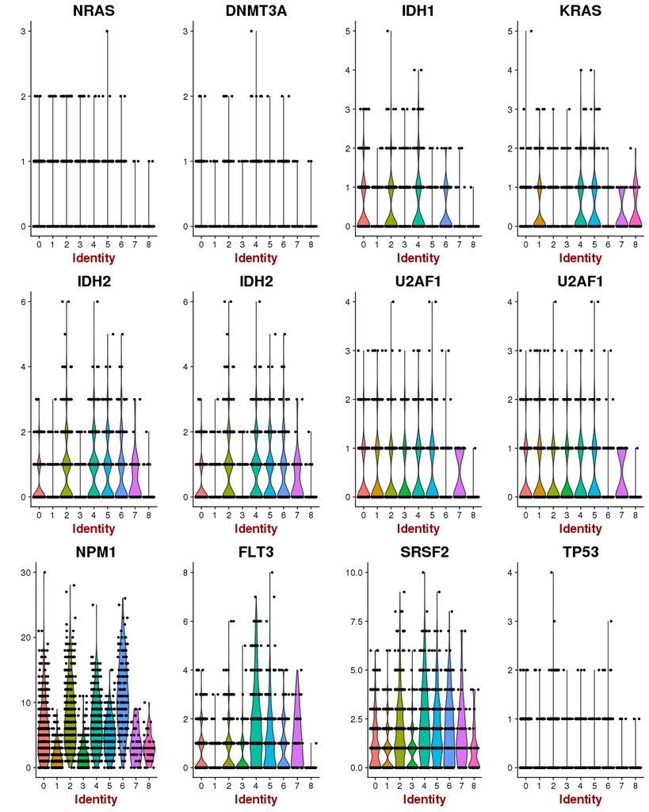

```r
VlnPlot(object = aml_comb, features.plot = c("NRAS", "DNMT3A",  "IDH1", "KRAS", "IDH2", "IDH2", "U2AF1",
                                        "U2AF1",    "NPM1", "FLT3", "SRSF2",    "TP53"),use.raw = TRUE, y.log = FALSE)
```

Plot the cells with cancer markers from Ley lab

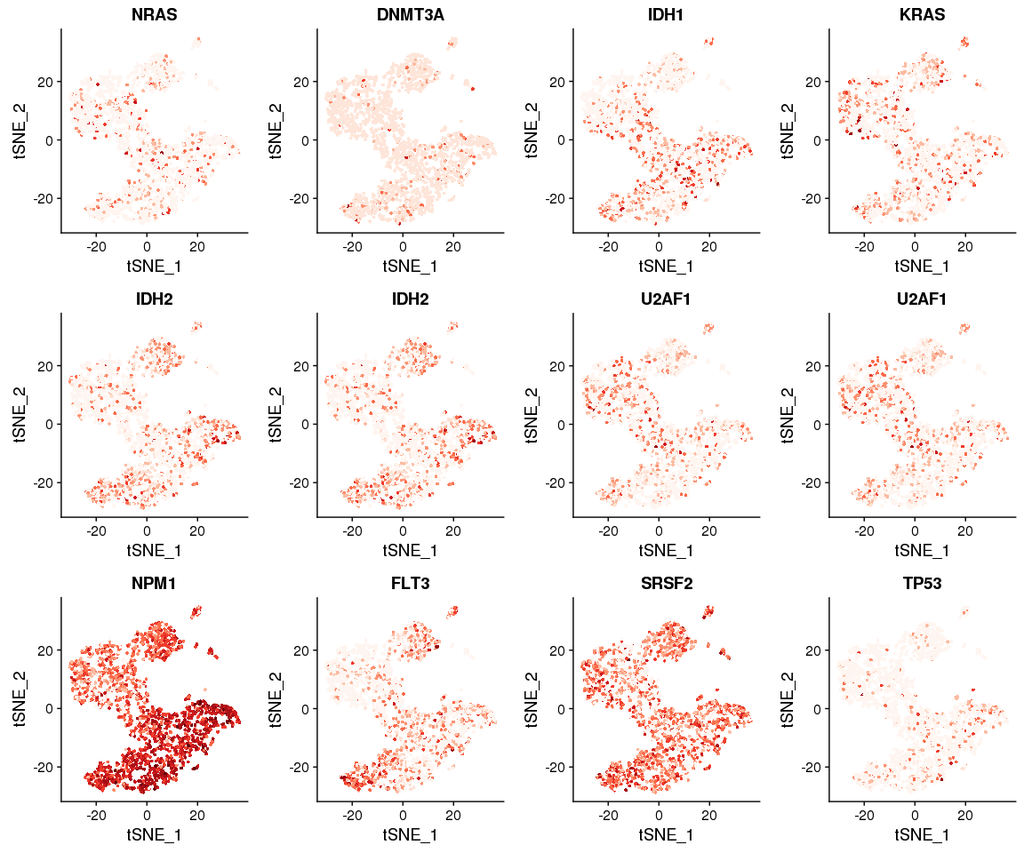

```r
FeaturePlot(object = aml_comb, features.plot = c("NRAS", "DNMT3A",  "IDH1", "KRAS", "IDH2", "IDH2", "U2AF1",
                                        "U2AF1",    "NPM1", "FLT3", "SRSF2",    "TP53"), cols.use = c("Reds"),reduction.use = "tsne")
```

Plot the cells with cell type markers

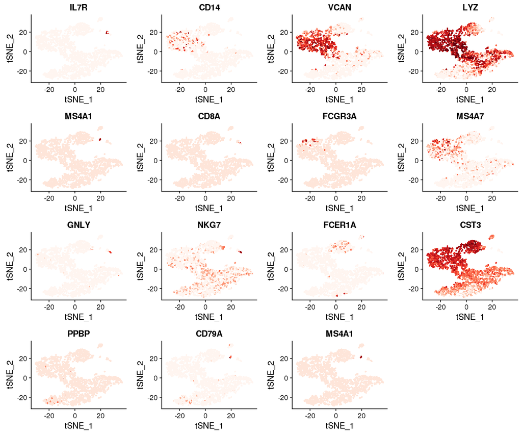

```r
FeaturePlot(object = aml_comb, features.plot = c("IL7R","CD14", "VCAN", "LYZ","MS4A1", "CD8A","FCGR3A",
                                            "MS4A7","GNLY", "NKG7","FCER1A", "CST3","PPBP",
                                            "CD79A", "MS4A1"), cols.use = c("Reds"),reduction.use = "tsne")
```

Plot the cells with cell type markers - Dendrocytes only

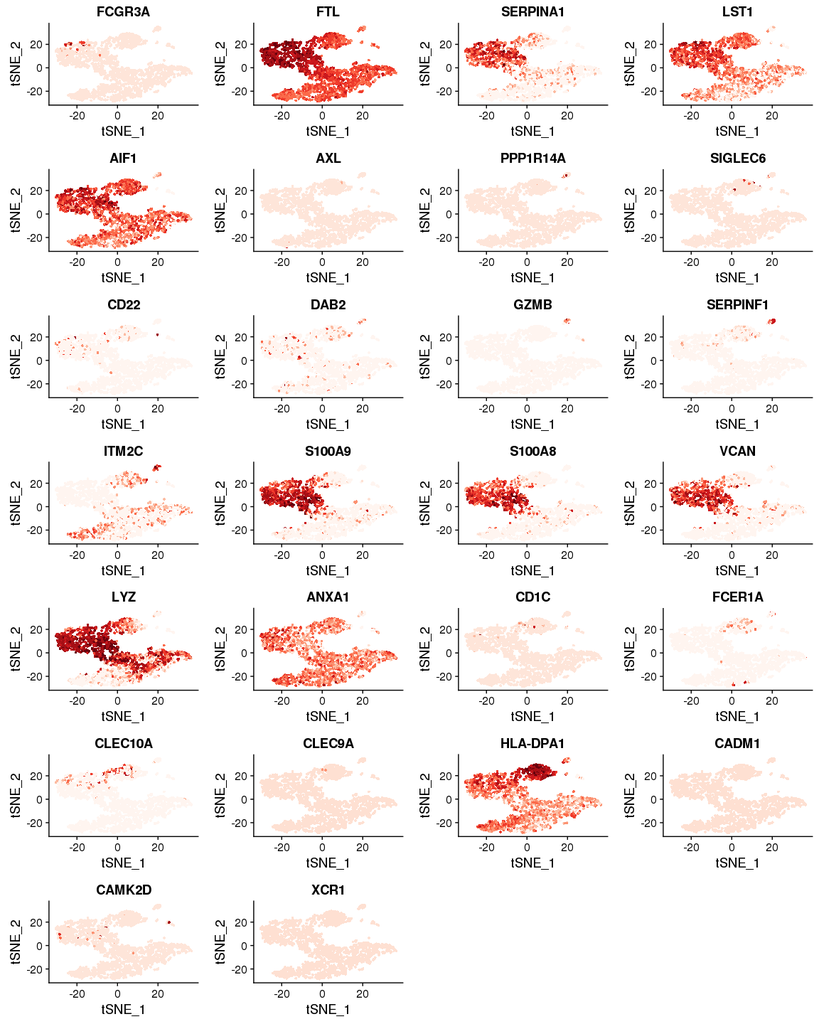

```r
FeaturePlot(object = aml_comb, features.plot = c("FCGR3A","FTL", "SERPINA1", "LST1","AIF1", "AXL","PPP1R14A",
                                            "SIGLEC6","CD22", "DAB2","GZMB",
                                            "SERPINF1", "ITM2C", "S100A9","S100A8", "VCAN","LYZ", "ANXA1","CD1C",
                                            "FCER1A", "CLEC10A","CLEC9A", "HLA-DPA1", "CADM1","CAMK2D","XCR1"), cols.use = c("Reds"),reduction.use = "tsne")
```

```r
# Here can also get the ggplot objects by. Plots can be investigated individually by a$yourgene
# a <- FeaturePlot(object = aml_comb, features.plot = c("FCGR3A","FTL", "SERPINA1", "LST1","AIF1", "AXL","PPP1R14A",
#                                             "SIGLEC6","CD22", "DAB2","GZMB",
#                                             "SERPINF1", "ITM2C", "S100A9","S100A8", "VCAN","LYZ", "ANXA1","CD1C",
#                                             "FCER1A", "CLEC10A","CLEC9A", "HLA-DPA1", "CADM1","CAMK2D","XCR1"), cols.use = c("Reds"),reduction.use = "tsne",
#             do.return = TRUE)
```

Heatmaps of top genes

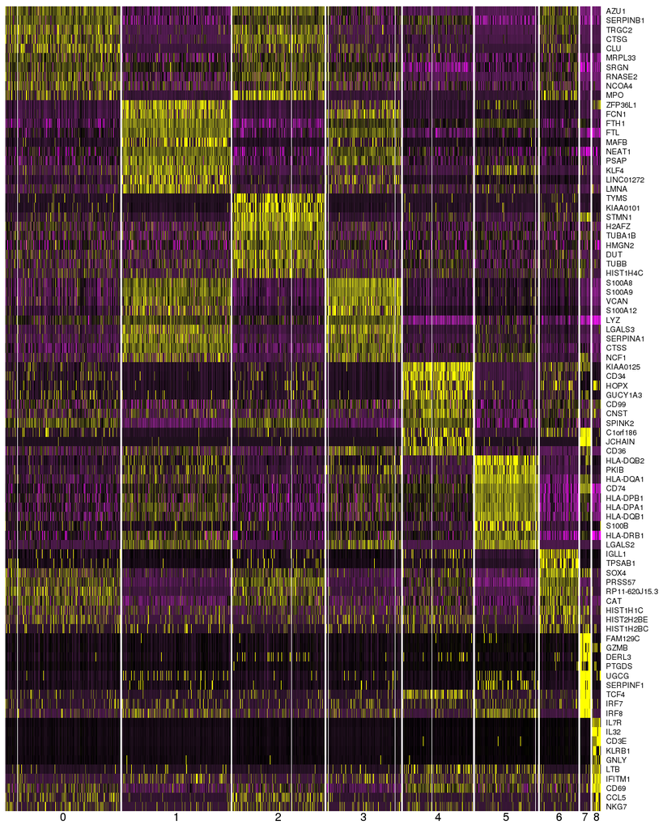

```r
top10 <- aml_comb.markers %>% group_by(cluster) %>% top_n(10, avg_logFC)
# setting slim.col.label to TRUE will print just the cluster IDS instead of
# every cell name
DoHeatmap(object = aml_comb, genes.use = top10$gene, slim.col.label = TRUE, remove.key = TRUE)
```

Assign cells (This needs to be adjusted)

```r
# current.cluster.ids <- c(0, 1, 2, 3, 4, 5, 6, 7)
# new.cluster.ids <- c("CD4 T cells", "CD14+ Monocytes", "B cells", "CD8 T cells",
#     "FCGR3A+ Monocytes", "NK cells", "Dendritic cells", "Megakaryocytes")
# aml_comb@ident <- plyr::mapvalues(x = aml_comb@ident, from = current.cluster.ids, to = new.cluster.ids)
# TSNEPlot(object = aml_comb, do.label = TRUE, pt.size = 0.5)
```